# Bi-weekly Assignment Week 3: Apply tf-idf scheme to non-text data context.

Shyni David

1/24/2019

Library set up

```r
library(tidyverse)
library(tidytext)
```

Import data

```r
setwd("~/Desktop/FISHER SMB-A/Term 3/Descriptive Analytics/Week 3")
smba <- read_csv("sp19-student-kaggle.csv" )
```

1.Compute tf, idf, and tf-idf. Print in the report the top 10 student-kaggle data pairs in each of tf, idf, and tf-idf.

```r
smba1 <- smba %>%
  mutate(ds_num =row_number())

smba1 %>%
group_by(Name) %>%
summarize(n=n(), rating = mean(Weight)) %>% arrange(-n, -rating)
```

```
## # A tibble: 30 x 3
##    Name                  n rating
##    <chr>             <int>  <dbl>
##  1 Aaron Thomas          5     20
##  2 Alex Duquenne         5     20
##  3 Alex Webel            5     20
##  4 Brandi Cade           5     20
##  5 Brian Stamper         5     20
##  6 Chris Owens           5     20
##  7 Danielle Lumbatis     5     20
##  8 David Pickering       5     20
##  9 Esther See            5     20
## 10 Ian Cunningham        5     20
## # … with 20 more rows
```

```r
#Convert to tidy text format
tidy_smba <- smba1 %>%
  unnest_tokens(word, Kaggle)

tidy_smba %>%
  count(word, sort=T)
```

```
## # A tibble: 328 x 2
##    word        n
##    <chr>   <int>
##  1 data       25
##  2 us         15
##  3 in         11
##  4 reviews     9
##  5 dataset     8
##  6 world       7
##  7 and         6
##  8 netflix     6
##  9 new         6
## 10 cans        5
## # … with 318 more rows
```

```r
#Stop words
data("stop_words")

#Removing numbers
nums <- tidy_smba %>%
  filter(str_detect(word, "^[0-9]")) %>%
  select(word) %>% unique()


#Stemming
#final tidy data
library(SnowballC)
tidy_smba_1 <- tidy_smba %>%
  anti_join(stop_words) %>%
  anti_join(nums) %>%
  mutate(root = wordStem(word))
tidy_smba_1 %>%  count(word, sort=T)
```

```
## # A tibble: 307 x 2
##    word                n
##    <chr>           <int>
##  1 data               25
##  2 reviews             9
##  3 dataset             8
##  4 world               7
##  5 netflix             6
##  6 cans                5
##  7 craft               5
##  8 creditcardfraud     5
##  9 market              5
## 10 mlg                 5
## # … with 297 more rows
```

```r
tidy_smba_1 %>%  count(root, sort=T)
```

```
## # A tibble: 298 x 2
##    root                n
##    <chr>           <int>
##  1 data               25
##  2 dataset             9
##  3 review              9
##  4 world               7
##  5 netflix             6
##  6 can                 5
##  7 craft               5
##  8 creditcardfraud     5
##  9 incom               5
## 10 market              5
## # … with 288 more rows
```

```r
#computing tf
prods_smba <- tidy_smba_1 %>% count(Name) %>% mutate(prod_id = row_number()) %>% select(-n)


words_smba <- tidy_smba_1 %>% left_join(prods_smba) %>% group_by(prod_id) %>% count(root, sort=T) %>% ungroup()
totals_smba<- words_smba %>% group_by(prod_id) %>% summarize(total=sum(n))

words_smba <- left_join(words_smba, totals_smba)
freq_by_rank <- words_smba %>% group_by(prod_id) %>% mutate(rank=row_number(), tf=n/total) %>% ungroup()

#computing idf
tidy_smba_1 %>% left_join(prods_smba) %>%
group_by(root) %>% summarize(ndocs=n_distinct(prod_id)) %>% arrange(-ndocs) %>% mutate(idf=log(nrow(prods_smba)/ndocs)) %>% print(n=10)
```

```
## # A tibble: 298 x 3
##    root            ndocs   idf
##    <chr>           <int> <dbl>
##  1 data               21 0.357
##  2 dataset             8 1.32
##  3 review              7 1.46
##  4 world               7 1.46
##  5 can                 5 1.79
##  6 craft               5 1.79
##  7 creditcardfraud     5 1.79
##  8 market              5 1.79
##  9 mlg                 5 1.79
## 10 nickhould           5 1.79
## # … with 288 more rows
```

```r
library(sqldf)
sqldf("select * from tidy_smba_1 where word like '%can%'")
```

```
##                   Name Weight ds_num                  word
## 1          Shyni David     20     28 breastcancerproteomes
## 2        Matthew Davis     25     32                  cans
## 3           John Ellis     10     50                  cans
## 4      Matthew Fleming     20     51                cancer
## 5         Manish Kumar     30     74                  cans
## 6          Chris Owens     30    106                  cans
## 7      David Pickering     25    118                  cans
## 8 Shannon Poffenberger     25    121              cannabis
## 9           Esther See     23    128               volcano
##                  root
## 1 breastcancerproteom
## 2                 can
## 3                 can
## 4              cancer
## 5                 can
## 6                 can
## 7                 can
## 8             cannabi
## 9             volcano
```

```r
#root word can is for cancer, cans, cannabis so will not use stemming
#@@@@@@@
tidy_smba_1 <- tidy_smba %>%
  anti_join(stop_words) %>%
  anti_join(nums)
tidy_smba_1 %>%  count(word, sort=T)
```

```
## # A tibble: 307 x 2
##    word                n
##    <chr>           <int>
##  1 data               25
##  2 reviews             9
##  3 dataset             8
##  4 world               7
##  5 netflix             6
##  6 cans                5
##  7 craft               5
##  8 creditcardfraud     5
##  9 market              5
## 10 mlg                 5
## # … with 297 more rows
```

```r
#computing tf
prods_smba <- tidy_smba_1 %>% count(Name) %>% mutate(prod_id = row_number()) %>% select(-n)


words_smba <- tidy_smba_1 %>% left_join(prods_smba) %>% group_by(prod_id) %>% count(word, sort=T) %>% ungroup()
totals_smba<- words_smba %>% group_by(prod_id) %>% summarize(total=sum(n))

words_smba <- left_join(words_smba, totals_smba)
freq_by_rank <- words_smba %>% group_by(prod_id) %>% mutate(rank=row_number(), tf=n/total) %>% ungroup()

#computing idf
tidy_smba_1 %>% left_join(prods_smba) %>%
group_by(word) %>% summarize(ndocs=n_distinct(prod_id)) %>% arrange(-ndocs) %>% mutate(idf=log(nrow(prods_smba)/ndocs)) %>% print(n=10)
```

```
## # A tibble: 307 x 3
##    word            ndocs   idf
##    <chr>           <int> <dbl>
##  1 data               21 0.357
##  2 dataset             7 1.46
##  3 reviews             7 1.46
##  4 world               7 1.46
##  5 cans                5 1.79
##  6 craft               5 1.79
##  7 creditcardfraud     5 1.79
##  8 market              5 1.79
##  9 mlg                 5 1.79
## 10 nickhould           5 1.79
## # … with 297 more rows
```

```r
#@@@@@@

#Shortcut to computing tf-idf statistic
tfidf_smba <- words_smba %>% bind_tf_idf(word, prod_id, n)

tfidf_smba  %>% arrange(-tf_idf) %>% print(n=10)
```

```
## # A tibble: 535 x 7
##    prod_id word               n total     tf   idf tf_idf
##      <int> <chr>          <int> <int>  <dbl> <dbl>  <dbl>
##  1      30 cms                2    13 0.154   3.40  0.523
##  2      27 yelp               2    17 0.118   3.40  0.400
##  3      16 netflix            2    13 0.154   2.30  0.354
##  4      29 inspections        2    23 0.0870  3.40  0.296
##  5      16 hugomathien        1    13 0.0769  3.40  0.262
##  6      16 soccer             1    13 0.0769  3.40  0.262
##  7      30 federalreserve     1    13 0.0769  3.40  0.262
##  8      30 medicare           1    13 0.0769  3.40  0.262
##  9      30 nsharan            1    13 0.0769  3.40  0.262
## 10      30 rates              1    13 0.0769  3.40  0.262
## # … with 525 more rows
```

Print the value of tf, idf, tf_idf along with each student-kaggle data pair.

```r
tfidf_smba_join <- left_join(tfidf_smba, prods_smba, by = c("prod_id" = "prod_id" ))

smba_join1 <- left_join(tfidf_smba_join, smba1, by = c("Name" = "Name" ))


library(stringr)
final_tf_idf <- smba_join1 %>%  filter(str_detect(smba_join1$Kaggle, smba_join1$word))

str(final_tf_idf)
```

```
## Classes 'tbl_df', 'tbl' and 'data.frame':    557 obs. of  11 variables:
##  $ prod_id: int  2 6 6 8 8 8 13 13 13 14 ...
##  $ word   : chr  "chicago" "data" "data" "data" ...
##  $ n      : int  2 2 2 2 2 2 2 2 2 2 ...
##  $ total  : int  21 21 21 19 19 19 22 22 22 22 ...
##  $ tf     : num  0.0952 0.0952 0.0952 0.1053 0.1053 ...
##  $ idf    : num  2.708 0.357 0.357 0.357 0.357 ...
##  $ tf_idf : num  0.2579 0.034 0.034 0.0375 0.0375 ...
##  $ Name   : chr  "Alex Duquenne" "Chris Owens" "Chris Owens" "David Pickering" ...
##  $ Kaggle : chr  "chicago/chicago-crime" "tobycrabtree/nfl-scores-and-betting-data" "grantruedy/pga-tour-golf-data-2017-season" "wendykan/lending-club-loan-data" ...
##  $ Weight : num  20 20 20 10 5 5 20 30 25 25 ...
##  $ ds_num : int  43 109 110 117 119 119 112 114 115 87 ...
```

```r
final_tf_idf %>% select(-Weight, -n, -total, -ds_num, -prod_id) %>% arrange(-tf-idf)
```

```
## # A tibble: 557 x 6
##    word          tf   idf tf_idf Name        Kaggle
##    <chr>      <dbl> <dbl>  <dbl> <chr>       <chr>
##  1 cms       0.154   3.40  0.523 Tasneem Mo… cms/cms-medicare
##  2 yelp      0.118   3.40  0.400 Shannon Po… yelp-dataset/yelp-dataset
##  3 inspecti… 0.0870  3.40  0.296 Sophia Lai  new-york-state/nys-retail-foo…
##  4 inspecti… 0.0870  3.40  0.296 Sophia Lai  chicago/chi-restaurant-inspec…
##  5 hugomath… 0.0769  3.40  0.262 Kunal Gupta hugomathien/soccer
##  6 soccer    0.0769  3.40  0.262 Kunal Gupta hugomathien/soccer
##  7 federalr… 0.0769  3.40  0.262 Tasneem Mo… federalreserve/interest-rates
##  8 medicare  0.0769  3.40  0.262 Tasneem Mo… cms/cms-medicare
##  9 nsharan   0.0769  3.40  0.262 Tasneem Mo… nsharan/h-1b-visa
## 10 rates     0.0769  3.40  0.262 Tasneem Mo… federalreserve/interest-rates
## # … with 547 more rows
```

```r
final_tf_idf
```

```
## # A tibble: 557 x 11
##    prod_id word      n total     tf   idf tf_idf Name  Kaggle Weight ds_num
##      <int> <chr> <int> <int>  <dbl> <dbl>  <dbl> <chr> <chr>   <dbl>  <int>
##  1       2 chic…     2    21 0.0952 2.71  0.258  Alex… chica…     20     43
##  2       6 data      2    21 0.0952 0.357 0.0340 Chri… tobyc…     20    109
##  3       6 data      2    21 0.0952 0.357 0.0340 Chri… grant…     20    110
##  4       8 data      2    19 0.105  0.357 0.0375 Davi… wendy…     10    117
##  5       8 data      2    19 0.105  0.357 0.0375 Davi… netfl…      5    119
##  6       8 netf…     2    19 0.105  2.30  0.242  Davi… netfl…      5    119
##  7      13 data      2    22 0.0909 0.357 0.0324 Jona… shrut…     20    112
##  8      13 data      2    22 0.0909 0.357 0.0324 Jona… pavan…     30    114
##  9      13 data      2    22 0.0909 0.357 0.0324 Jona… rhueb…     25    115
## 10      14 fifa      2    22 0.0909 2.71  0.246  Josh… stefa…     25     87
## # … with 547 more rows
```

```r
range(tfidf_smba$total)
```

```
## [1] 13 23
```

```r
tfidf_vis_smba <- tfidf_smba %>% filter(total > 18) %>% group_by(prod_id) %>% top_n(15) %>% ungroup() %>% arrange(prod_id, -tf_idf) %>% mutate(order=row_number())
```

[figure not shown]

```r
      facet_order <- tidy_smba_1 %>% count(Name) %>%
        mutate(prod_id = row_number()) %>%
        arrange(-n) %>% head(10)

tfidf_vis_smba %>%
ggplot(aes(order, tf_idf, fill=factor(prod_id))) + geom_col(show.legend=F) +
scale_x_reverse(
          breaks=tfidf_vis_smba$order,
          labels=tfidf_vis_smba$root,
          expand=c(0,0)) +
        labs(x=NULL, y="tf-idf") +
        facet_wrap(
~factor(prod_id, levels=facet_order$prod_id),
          ncol=2, scales="free") +
        coord_flip()
```

Q Compute cosine similarities between you and all other students using the tf-idf statistics normalized by L2 norm. (10 pts)

```r
library(quanteda)
library(text2vec)

dfm_smba <- tidy_smba_1 %>% left_join(prods_smba) %>%
group_by(prod_id) %>%
count(word) %>%
cast_dfm(term=word, document=prod_id, n)
 dfm_tfidf_smba <- dfm_tfidf(dfm_smba)
cossims <- sim2(dfm_tfidf_smba, dfm_tfidf_smba, method="cosine", norm="l2")
td_sims <- as.tibble(tidy(cossims))
td_sims
```

```
## # A tibble: 584 x 3
##    row   column    value
##    <chr> <chr>     <dbl>
##  1 1     1      1
##  2 2     1      0.000804
##  3 3     1      0.00127
##  4 4     1      0.428
##  5 5     1      0.000810
##  6 6     1      0.258
##  7 8     1      0.00208
##  8 10    1      0.000853
##  9 11    1      0.0842
## 10 12    1      0.0856
## # … with 574 more rows
```

```r
sqldf("select * from td_sims where row = '28' or column = '28'")
```

```
##    row column      value
## 1   28      1 0.01466108
## 2   28      9 0.09630595
## 3   28     11 0.01609277
## 4   28     13 0.01562605
## 5   28     17 0.01639574
## 6   28     18 0.01290223
## 7    1     28 0.01466108
## 8    9     28 0.09630595
## 9   11     28 0.01609277
## 10  13     28 0.01562605
## 11  17     28 0.01639574
## 12  18     28 0.01290223
## 13  28     28 1.00000000
## 14  29     28 0.01118063
## 15  28     29 0.01118063
```

Q.According to the cosine similarities you computed above, who (other than yourself) is (are) most similar to you in terms of their weighted choice of Kaggle datasets? Name all if multiple people tie.

Q.Train an LDA model with two topics. Create the following three visualizations.

```r
#install.packages("topicmodels")
library(topicmodels)
dtm_smba <- tidy_smba %>% left_join(prods_smba) %>%
group_by(prod_id) %>%
count(word) %>%
cast_dtm(term=word, document=prod_id, n)
lda_smba <- LDA(dtm_smba, k=2)
lda_smba
```

```
## A LDA_VEM topic model with 2 topics.
```

Visualization on page 40 in Week3-Lecture-Share.pdfPreview the document, showing the probabilities between students and topics.

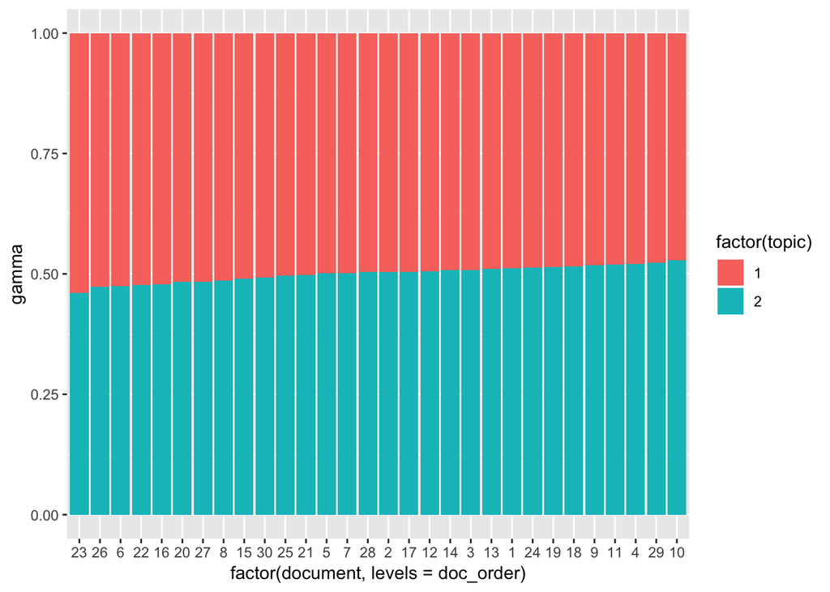

```r
lda_docs <- tidy(lda_smba, matrix="gamma")
doc_order <- lda_docs %>% filter(topic==1) %>% arrange(-gamma) %>% pull(document)
lda_docs %>% arrange(topic, -gamma) %>%
ggplot(aes(x=factor(document, levels=doc_order), y=gamma, fill=factor(topic))) + geom_col()
```

```r
prods_smba %>% arrange(factor(prod_id, levels=doc_order)) %>% print(n=23)
```

```
## # A tibble: 30 x 2
##    Name                 prod_id
##    <chr>                  <int>
##  1 Matthew Fleming           23
##  2 Sarah Condon              26
##  3 Chris Owens                6
##  4 Matthew Davis             22
##  5 Kunal Gupta               16
##  6 Mary McClain              20
##  7 Shannon Poffenberger      27
##  8 David Pickering            8
##  9 Kristopher Koloini        15
## 10 Tasneem Motiwala          30
## 11 Samantha Day              25
## 12 Matt Hawes                21
## 13 Brian Stamper              5
## 14 Danielle Lumbatis          7
## 15 Shyni David               28
## 16 Alex Duquenne              2
## 17 Manish Kumar              17
## 18 John Ellis                12
## 19 Josh Mark                 14
## 20 Alex Webel                 3
## 21 Jonathan Parry            13
## 22 Aaron Thomas               1
## 23 Megan Appelt              24
## # … with 7 more rows
```

Visualization on page 41 in Week3-Lecture-Share.pdfPreview the document, showing the probabilities between Kaggle datasets and topics.

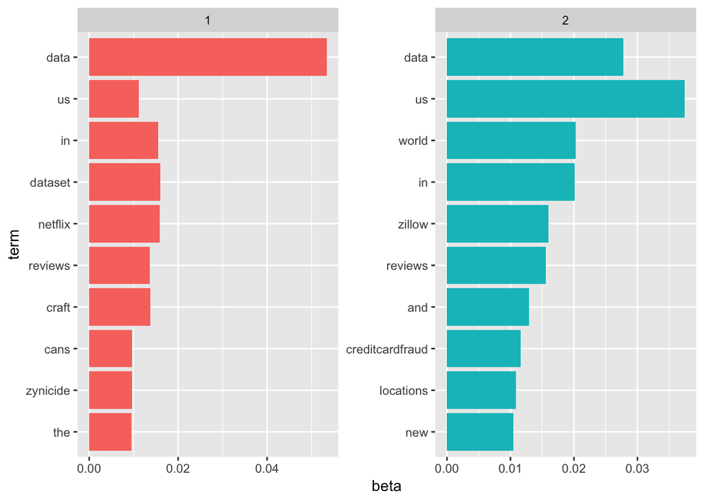

```r
lda_topics <- tidy(lda_smba, matrix="beta")
top_topics <- lda_topics %>%
  group_by(topic) %>% top_n(10, beta) %>%
  ungroup() %>% arrange(topic, -beta)
top_topics %>%
mutate(term=reorder(term, beta)) %>% ggplot() + geom_col(aes(term, beta, fill=factor(topic)), show.legend=F) + facet_wrap(~topic, scale="free") + coord_flip()
```

```r
  top_topics
```

```
## # A tibble: 20 x 3
##    topic term               beta
##    <int> <chr>             <dbl>
##  1     1 data            0.0534
##  2     1 dataset         0.0159
##  3     1 netflix         0.0159
##  4     1 in              0.0155
##  5     1 craft           0.0138
##  6     1 reviews         0.0136
##  7     1 us              0.0111
##  8     1 cans            0.00966
##  9     1 zynicide        0.00957
## 10     1 the             0.00948
## 11     2 us              0.0374
## 12     2 data            0.0277
## 13     2 world           0.0202
## 14     2 in              0.0201
## 15     2 zillow          0.0160
## 16     2 reviews         0.0156
## 17     2 and             0.0129
## 18     2 creditcardfraud 0.0116
## 19     2 locations       0.0109
## 20     2 new             0.0105
```

Visualization on page 42 in Week3-Lecture-Share.pdfPreview the document, showing the most differentiating words for both topics.

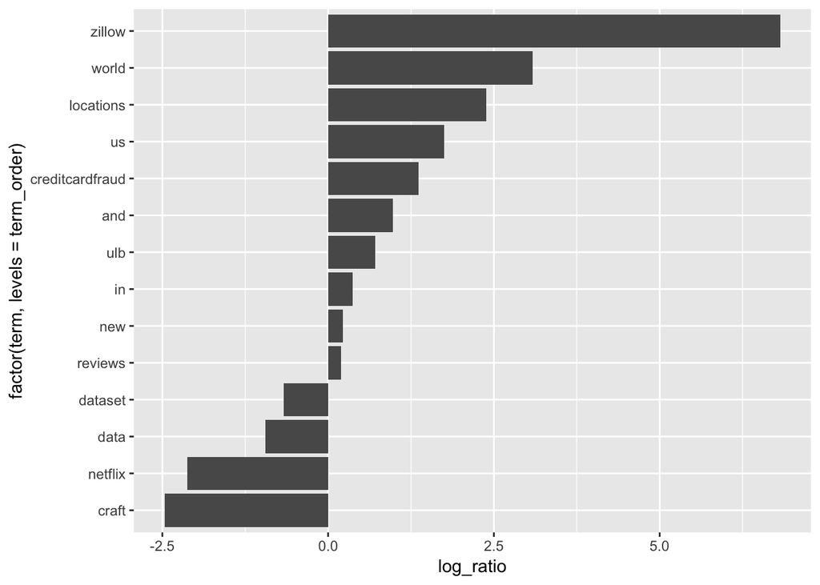

```r
beta_spread <- lda_topics %>%
mutate(topic = paste0("topic", topic)) %>% spread(topic, beta) %>% filter(topic1>.01|topic2>.01) %>% mutate(log_ratio=log2(topic2/topic1)) %>% arrange(log_ratio)
term_order <- beta_spread$term
beta_spread %>% ggplot() +
geom_col(aes(factor(term, levels=term_order), log_ratio)) + coord_flip()
```

```r
beta_spread
```

```
## # A tibble: 14 x 4
##    term              topic1  topic2 log_ratio
##    <chr>              <dbl>   <dbl>     <dbl>
##  1 craft           0.0138   0.00249    -2.47
##  2 netflix         0.0159   0.00364    -2.12
##  3 data            0.0534   0.0277     -0.945
##  4 dataset         0.0159   0.0100     -0.669
##  5 reviews         0.0136   0.0156      0.199
##  6 new             0.00896  0.0105      0.226
##  7 in              0.0155   0.0201      0.372
##  8 ulb             0.00614  0.0101      0.711
##  9 and             0.00653  0.0129      0.981
## 10 creditcardfraud 0.00454  0.0116      1.36
## 11 us              0.0111   0.0374      1.75
## 12 locations       0.00208  0.0109      2.39
## 13 world           0.00239  0.0202      3.08
## 14 zillow          0.000142 0.0160      6.82
```